# A map of Japanese collectivism

Igor de Almeida

2021-04-04

This visualisation is based on Niwako Yamawaki’s academic article [1] and [Masaki Kubota’s R code](https://qiita.com/masaki_kubota/items/98ddec63492a8d71f9d1) [2].

Collectivism is defined in the Oxford dictionary as “the practice or principle of giving a group priority over each individual in it.”  
Yamawaki measured collectivism based on divorce to marriage rate, percentage of households with three generations living together, percentage of elderly people (aged 65+ years) living alone (reverse scored), percentage of nuclear family households (reverse scored), and percentage of people living alone (reverse scored). Then, a scale was created and each Japanese prefecture got a score. See details in the original article.

Here I got these scores of collectivism, combined with Kubora’s code, and made two tile maps of Japan.

```r
# Packages
library(dplyr)
```

```r
library(ggplot2)
library(readr)
```

```r
# Data with collectivism scores
jp_collectivism<- read_delim("jp_collectivism.csv",
                             ";", escape_double = FALSE, trim_ws = TRUE)
```

### Data necessary to plot the tile maps

```r
JP_plot <- tribble(
  ~Prefecture_jp,~Prefecture ,~Code, ~x, ~y,
  "北海道", "Hokkaido","HK", 16, 14,
  "青森","Aomori"　,"AO", 15, 11,
  "岩手","Iwate"　,"IT", 15, 10,
  "宮城","Miyagi"　,"MG", 15, 9,
  "秋田","Akita"　,"AK", 14, 10,
  "山形","Yamagata"　,"YG", 14, 9,
  "福島","Fukushima"　,"FS", 15, 8,
  "茨城","Ibaraki"　,"IB", 15, 6,
  "栃木","Tochigi"　,"TC", 15, 7,
  "群馬","Gunma"　,"GU", 14, 7,
  "埼玉","Saitama"　,"ST", 14, 6,
  "千葉","Chiba"　,"CB", 15, 5,
  "東京",　"Tokyo","TY", 14, 5,
  "神奈川","Kanagawa",　"KN", 14, 4,
  "新潟","Niigata",　"NI", 14, 8,
  "富山","Toyama",　"TM", 13, 7,
  "石川","Ishikawa",　"IS", 12, 7,
  "福井","Fukui",　"FI", 12, 6,
  "山梨","Yamanashi",　"YN", 13, 5,
  "長野","Nagano",　"NA", 13, 6,
  "岐阜","Gifu",　"GI", 12, 5,
  "静岡","Shizuoka",　"SZ", 13, 4,
  "愛知","Aichi",　"AI", 12, 4,
  "三重","Mie",　"ME", 11, 4,
  "滋賀","Shiga",　"SI", 11, 5,
  "京都","Kyoto",　"KY", 10, 5,
  "大阪","Osaka",　"OS", 9, 5,
  "兵庫","Hyogo",　"HG", 8, 5,
  "奈良","Nara",　"NR", 10, 4,
  "和歌山","Wakayama",　"WA", 9, 4,
  "鳥取","Tottori",　"TT", 7, 5,
  "島根","Shimane",　"SM", 6, 5,
  "岡山","Okayama",　"OY", 7, 4,
  "広島","Hiroshima",　"HS", 6, 4,
  "山口","Yamaguchi",　"YA", 5, 5,
  "徳島","Tokushima"　,"TK", 7, 1,
  "香川","Kagawa"　,"KA", 7, 2,
  "愛媛","Ehime"　,"EH", 6, 2,
  "高知","Kochi",　"KO", 6, 1,
  "福岡","Fukuoka"　,"FO", 4, 3,
  "佐賀","Saga"　,"SG", 3, 3,
  "長崎","Nagasaki",　"NS", 2, 3,
  "熊本","Kumamoto"　,"KU", 3, 2,
  "大分","Oita"　,"OI", 4, 2,
  "宮崎","Miyazaki"　,"MZ", 4, 1,
  "鹿児島","Kagoshima" ,"KG", 3, 1,
  "沖縄","Okinawa"　,"OK", 1, 1)

# Define Map sizes
JP_plot<- JP_plot %>% mutate(scale = c(3,rep(1,46)))# because Hokkaido is larger than the other prefectures
```

### Combining the data

```r
jp_collectivism<- jp_collectivism %>%  left_join(JP_plot,by= "Prefecture")
```

### Creating the graphs

```r
# Graph with latin alphabet labels
graph<- jp_collectivism %>% # data itself
  ggplot(aes(x = x, # x axis
             y = y, # y axis
             width = scale, # scale of width
             height = scale)) +  #scale of height
  geom_tile(aes(fill = Score), color = "black") + # variable used to calculate the colour filling of the tiles
 geom_text(aes(label = Code), size = 2.7, color = "red" ) +   # label and its size and colour
  coord_fixed(ratio = 1) +  # to keep the ratio between the representation of data and axis
  theme( # no background, axis, title, ticks or legend
    panel.background = element_blank(),
    panel.grid = element_blank(),
    axis.title = element_blank(),
    axis.text = element_blank(),
    axis.ticks = element_blank(),
    legend.position = "none")  +

  scale_fill_gradient2(low="black", # gradient colours
                     mid="#DDDDDD",
                     high="grey50",
                     midpoint = 50) # gradient midpoint

# Graph with Japanese labels
graph1<- jp_collectivism %>% # data itself
  ggplot(aes(x = x, # x axis
             y = y, # y axis
             width = scale, # scale of width
             height = scale)) +  #scale of height
  geom_tile(aes(fill = Score), color = "black") + # variable used to calculate the colour filling of the tiles
 geom_text(aes(label = Prefecture_jp), size = 2.7, color = "black" ) +   # label and its size and colour
  coord_fixed(ratio = 1) +  # to keep the ratio between the representation of data and axis
  theme( # no background, axis, title, ticks or legend
    panel.background = element_blank(),
    panel.grid = element_blank(),
    axis.title = element_blank(),
    axis.text = element_blank(),
    axis.ticks = element_blank(),
    legend.position = "none")  +

  scale_fill_gradient2(low="grey90", # gradient colours
                     mid="steelblue",
                     high="blue",
                     midpoint = 50
                     ) # gradient midpoint
```

### Plotting the graphs

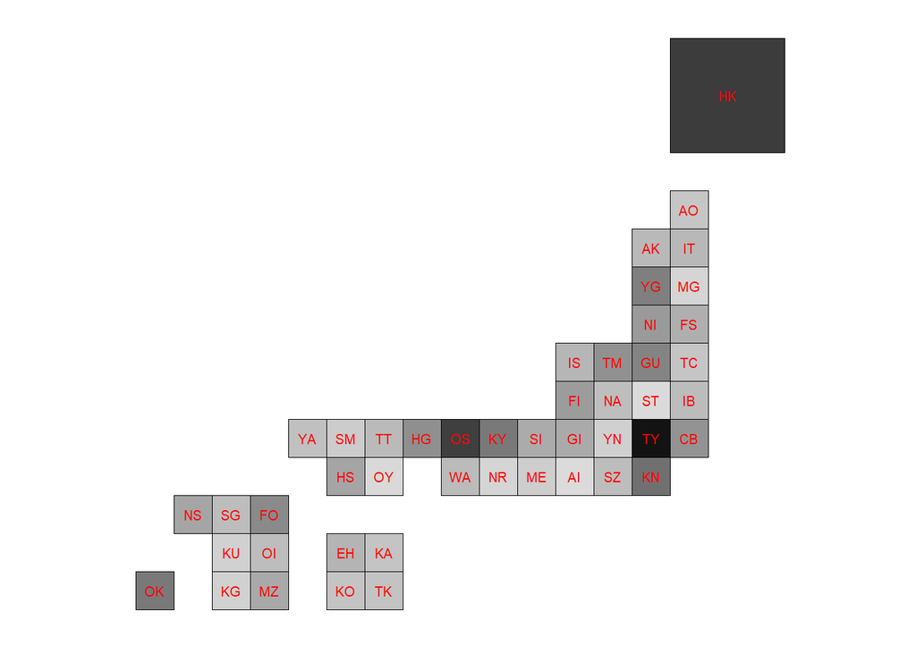

```r
print(graph)
```

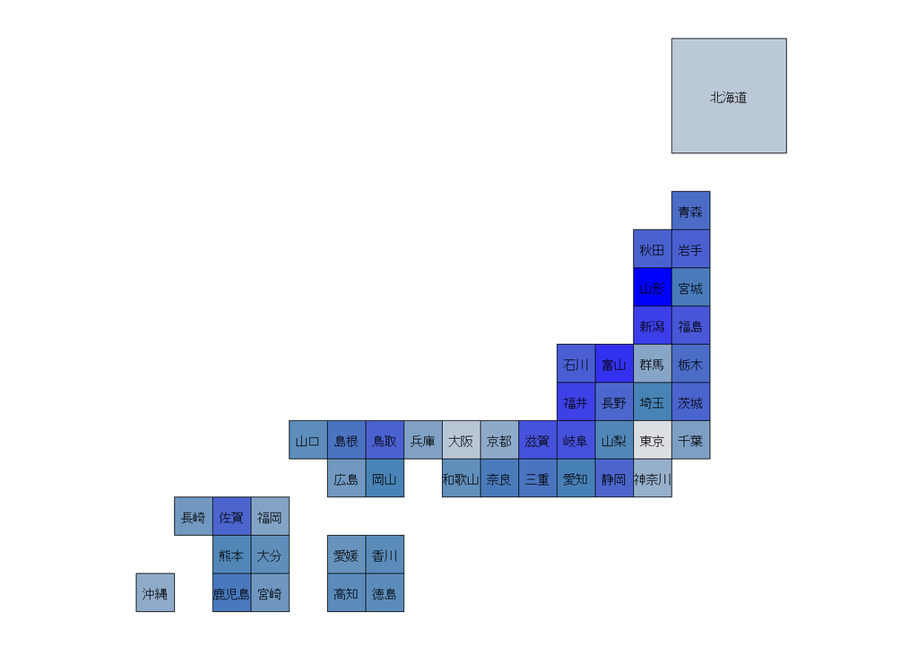

```r
print(graph1)
```

[1] Yamawaki, N. (2012). Within-culture variations of collectivism in Japan. Journal of Cross-Cultural Psychology, 43(8), 1191-1204.